# How to Create a Time Series With Excel or Google Sheets

The following page will show us how to make a time series in using google sheets in 3 steps. The process is very similar with excel. The data in this presentation can be found at www.census.gov and sealevel.nasa.gov.

### 1 - Find your dataset

The first step will be finding a dataset and it is very important to find it from a reliable source. We will be working with population data, so our best source will be the Census Bureau. Sheets and Excel work best with .xls, .csv, or .txt. Once you find a dataset you can download it to your computer

### 2 - Import the Dataset

Next we will import our data. Go to “File”, then “Import”

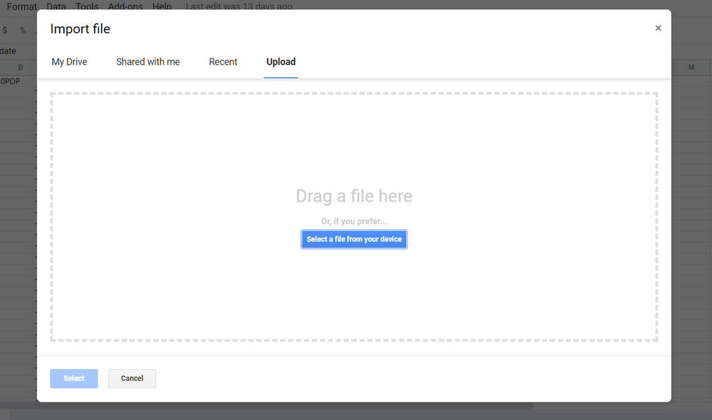

You should be prompted by this window. We can now just drag our file from the File Explorer and place it in the upload box. Now we have our data!

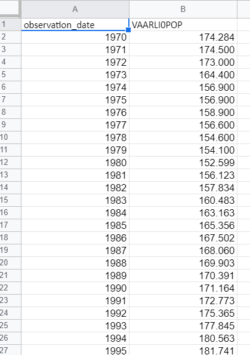

### 3 - Plotting the Data

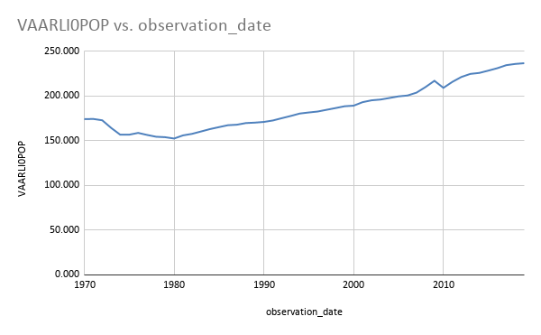

Now, a chart has appeared. If you not like the default aesthetics, you can customize the chart using the “Setup” and “Customize” tabs on the right side of the Sheets window. Once you set up some of the aesthetics you can get a graph that looks like this. Within the settings, we can change the titles, axis labels, colors, ect.

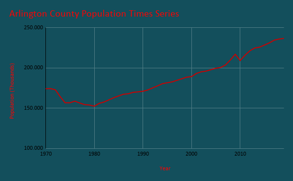

Here is another example using global mean sea level increase. This is just another example using different aesthetics options.

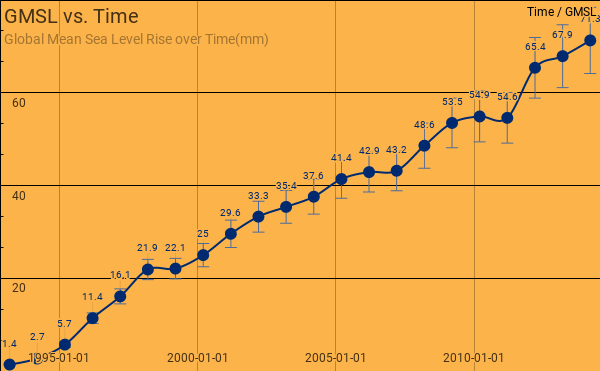